# Rocchio_Assignment8

Management Problem:

Suppose management is thinking about using a language model to classify written customer reviews and call and complaint logs. If the most critical customer messages can be identified, then customer support personnel can be assigned to contact those customers.

How would you advise senior management? What kinds of systems and methods would be most relevant to the customer services function? Considering the results of this assignment in particular, what is needed to make an automated customer support system that is capable of identifying negative customer feelings? What can data scientists do to make language models more useful in a customer service function?

Answer:

Utalizing this to determine the most critical reviews would be an effective method to study customer service. So the first thing that I would think of with this would be how the customer data ends up in text before it can go into the language model. You would have to outsource voice to text technology and implement it in the call center which can be difficult.

You would also need, because this is a deep learning model, a huge amount of data and the necessary storage and processing power for the data science team. This being said, the length of the customer converstions would be a large factor, additionally data protection would be an issue. Alot of companies ask security questions over the phone and you dont want that stored anywhere it doesnt need to be.

Regarding how to identify negative experiences; I would really wonder how we would consider a negative customer experience and say that it all depends on the company. Who would provide that? would it be the customer, call center rep, or would you need to allocate resources to a third party( which could be internal or external) to detemine if this is the type of call that needs to be studied.

Finally, NLP models are very useful in customer service settings and it brings the capability of deep learning to that department within companies. Traditionally customer service departments were locked out of analytics because there was no good way to quantify text and feed it into an algorithm. But NLP models changed all that!

```python
from google.colab import files
files.upload()
```

Upload widget is only available when the cell has been executed in the current browser session. Please rerun this cell to enable.

```
Saving kaggle.json to kaggle.json
```

```
{'kaggle.json': b'{"username":"michaelrocchio","key":"fcb9d1568595e76eab4ba8e2b41f9ff4"}'}
```

```python
!mkdir /root/.kaggle
```

```
mkdir: cannot create directory ‘/root/.kaggle’: File exists
```

```python
!mv /content/kaggle.json /root/.kaggle/kaggle.json
```

```python
!ls /root/.kaggle
```

```
kaggle.json
```

```python
import kaggle
!kaggle competitions download -c nlp-getting-started
```

```python
import pandas as pd
import numpy as np
import warnings
# warnings.filterwarnings('ignore')
import matplotlib.pyplot as plt
import plotly.graph_objects as go
import plotly.express as px
plt.style.use('fivethirtyeight')
import re
import string
import tensorflow as tf
from tensorflow.keras import layers
from tensorflow.keras.layers import Dense, Input, Embedding, LSTM
from tensorflow.keras.optimizers import Adam
from tensorflow.keras.models import Model
from tensorflow.keras.callbacks import ModelCheckpoint, EarlyStopping, ReduceLROnPlateau, LearningRateScheduler
import matplotlib.pyplot as plt
import tensorflow as tf
import re
import nltk
```

```python
train_df=pd.read_csv('/content/train.csv')
test_df=pd.read_csv('/content/test.csv')
print(train_df.shape)
train_df=pd.concat([train_df,test_df])
train_df
```

```
(7613, 5)
```

|  | id | keyword | location | text | target |
| --- | --- | --- | --- | --- | --- |
| 0 | 1 | NaN | NaN | Our Deeds are the Reason of this #earthquake M... | 1.0 |
| 1 | 4 | NaN | NaN | Forest fire near La Ronge Sask. Canada | 1.0 |
| 2 | 5 | NaN | NaN | All residents asked to 'shelter in place' are ... | 1.0 |
| 3 | 6 | NaN | NaN | 13,000 people receive #wildfires evacuation or... | 1.0 |
| 4 | 7 | NaN | NaN | Just got sent this photo from Ruby #Alaska as ... | 1.0 |
| ... | ... | ... | ... | ... | ... |
| 3258 | 10861 | NaN | NaN | EARTHQUAKE SAFETY LOS ANGELES ÛÒ SAFETY FASTE... | NaN |
| 3259 | 10865 | NaN | NaN | Storm in RI worse than last hurricane. My city... | NaN |
| 3260 | 10868 | NaN | NaN | Green Line derailment in Chicago http://t.co/U... | NaN |
| 3261 | 10874 | NaN | NaN | MEG issues Hazardous Weather Outlook (HWO) htt... | NaN |
| 3262 | 10875 | NaN | NaN | #CityofCalgary has activated its Municipal Eme... | NaN |

10876 rows × 5 columns

```python
!sudo apt-get install enchant
!sudo port install enchant2 +aspell +hunspell +applespell
!pip install pyenchant
!sudo apt-get install spellchecker
!pip install pyspellchecker
```

[output not shown]

```python
Note: I had to copy Stanford's Github for most of the preprocessing because of my lack of experience handling this type of data, for academic integrity purposes here is the GIT:
https://github.com/guillaume-chevalier/GloVe-as-a-TensorFlow-Embedding-Layer/blob/master/GloVe-as-TensorFlow-Embedding-Tutorial.ipynb
I also heavilly relied on the following notebook for guidence:
https://www.kaggle.com/shahules/basic-eda-cleaning-and-glove
```

```python
#### DATA CLEANING
# ! pip uninstall spellchecker
# ! pip install --requirement spellchecker


from spellchecker import *
import enchant

# !pip install nltk
nltk.download()
from nltk.corpus import stopwords
from nltk.tokenize import word_tokenize

def remove_URL(text):
    html= re.compile(r'<.*?>')
    url = re.compile(r'https?://\S+|www\.\S+')
    return url.sub(r'',html.sub(r'',text))
def remove_punct(text):
    table=str.maketrans('','',string.punctuation)
    return text.translate(table)
def remove_emoji(text):
    emoji_pattern = re.compile("["
                           u"\U0001F600-\U0001F64F"
                           u"\U0001F300-\U0001F5FF"
                           u"\U0001F680-\U0001F6FF"
                           u"\U0001F1E0-\U0001F1FF"
                           u"\U00002702-\U000027B0"
                           u"\U000024C2-\U0001F251"
                           "]+", flags=re.UNICODE)
    return emoji_pattern.sub(r'', text)

## lets fix bad spelling

spell = SpellChecker()
def bad_spelling(text):
    corrected_text = []
    misspelled_words = spell.unknown(text.split())
    for word in text.split():
        if word in misspelled_words:
            corrected_text.append(spell.correction(word))
        else:
            corrected_text.append(word)
    return " ".join(corrected_text)

test_text=('''This projects feels like a sick combination between literature and math class. Poor me😔😔.
Maybe I'll just get distracted at https://www.youtube.com. Thatll make me happy :), but then I will fail practical ML!!!!!
I could just drink some Covfefe!!!! Or is it spelled cofee or coffee?? My speling is awesume!!!''')

from nltk.tokenize import word_tokenize
stop_words=stopwords.words('english')
import nltk
nltk.download('punkt')
def remove_stop_words(text):
  text_tokens = word_tokenize(text)
  text = [word for word in text_tokens if not word in stop_words]
  text = (" ").join(text)
  return(text)

print('remove_stop words:')
print('')
test_text=remove_stop_words(test_text)
print(test_text)
print('')
print('')
test_text=remove_URL(test_text)
test_text=remove_punct(test_text)
print('remove_URL & punct:')
print(test_text)
print('')
print('')
test_text=remove_emoji(test_text)
print('')
print('remove_emoji:')
print(test_text)
print('bad_spelling:')
print(test_text)
test_text=bad_spelling(test_text)
print('')
```

```
NLTK Downloader
---------------------------------------------------------------------------
    d) Download   l) List    u) Update   c) Config   h) Help   q) Quit
---------------------------------------------------------------------------
Downloader> q
remove_stop words:

This projects feels like sick combination literature math class . Poor me😔😔 . Maybe I 'll get distracted https : //www.youtube.com . Thatll make happy : ) , I fail practical ML ! ! ! ! ! I could drink Covfefe ! ! ! ! Or spelled cofee coffee ? ? My speling awesume ! ! !


remove_URL & punct:
This projects feels like sick combination literature math class  Poor me😔😔  Maybe I ll get distracted https    Thatll make happy    I fail practical ML      I could drink Covfefe     Or spelled cofee coffee   My speling awesume



remove_emoji:
This projects feels like sick combination literature math class  Poor me  Maybe I ll get distracted https    Thatll make happy    I fail practical ML      I could drink Covfefe     Or spelled cofee coffee   My speling awesume
bad_spelling:
This projects feels like sick combination literature math class  Poor me  Maybe I ll get distracted https    Thatll make happy    I fail practical ML      I could drink Covfefe     Or spelled cofee coffee   My speling awesume
```

```python
remove_stop_words
train_df['text']=train_df['text'].apply(
    lambda x : remove_stop_words(x))
train_df['text']=train_df['text'].apply(
    lambda x : remove_URL(x))
train_df['text']=train_df['text'].apply(
    lambda x : remove_emoji(x))
train_df['text']=train_df['text'].apply(
    lambda x : remove_emoji(x))
from IPython.display import clear_output
# a=train_df['text'].to_list()
# length=len(a)
# count_done=0
# for i in a:
#   i=bad_spelling(i)
#   count_done=count_done+1
#   print('percent complete:', round(count_done/length,2))
#   clear_output(wait=True)
train_df
```

|  | id | keyword | location | text | target |
| --- | --- | --- | --- | --- | --- |
| 0 | 1 | NaN | NaN | Our Deeds Reason # earthquake May ALLAH Forgiv... | 1.0 |
| 1 | 4 | NaN | NaN | Forest fire near La Ronge Sask . Canada | 1.0 |
| 2 | 5 | NaN | NaN | All residents asked 'shelter place ' notified ... | 1.0 |
| 3 | 6 | NaN | NaN | 13,000 people receive # wildfires evacuation o... | 1.0 |
| 4 | 7 | NaN | NaN | Just got sent photo Ruby # Alaska smoke # wild... | 1.0 |
| ... | ... | ... | ... | ... | ... |
| 3258 | 10861 | NaN | NaN | EARTHQUAKE SAFETY LOS ANGELES ÛÒ SAFETY FASTE... | NaN |
| 3259 | 10865 | NaN | NaN | Storm RI worse last hurricane . My city & amp ... | NaN |
| 3260 | 10868 | NaN | NaN | Green Line derailment Chicago http : //t.co/Ut... | NaN |
| 3261 | 10874 | NaN | NaN | MEG issues Hazardous Weather Outlook ( HWO ) h... | NaN |
| 3262 | 10875 | NaN | NaN | # CityofCalgary activated Municipal Emergency ... | NaN |

10876 rows × 5 columns

```python
from tqdm import tqdm
def create_corpus(df):
    corpus=[]
    for tweet in tqdm(df['text']):
        words=[word.lower() for word in word_tokenize(tweet) if((word.isalpha()==1))]
        corpus.append(words)
    return corpus
```

```python
tweets_train=create_corpus(train_df)
print(tweets_train[:10])
```

```
[['our', 'deeds', 'reason', 'earthquake', 'may', 'allah', 'forgive', 'us'], ['forest', 'fire', 'near', 'la', 'ronge', 'sask', 'canada'], ['all', 'residents', 'asked', 'place', 'notified', 'officers', 'no', 'evacuation', 'shelter', 'place', 'orders', 'expected'], ['people', 'receive', 'wildfires', 'e…
```

```python
!pip install chakin
%matplotlib inline
import chakin
from google.colab import drive
chakin.search(lang='English')
```

```
                   Name  Dimension  ... Language    Author
2          fastText(en)        300  ...  English  Facebook
11         GloVe.6B.50d         50  ...  English  Stanford
12        GloVe.6B.100d        100  ...  English  Stanford
13        GloVe.6B.200d        200  ...  English  Stanford
14        GloVe.6B.300d        300  ...  English  Stanford
15       GloVe.42B.300d        300  ...  English  Stanford
16      GloVe.840B.300d        300  ...  English  Stanford
17    GloVe.Twitter.25d         25  ...  English  Stanford
18    GloVe.Twitter.50d         50  ...  English  Stanford
19   GloVe.Twitter.100d        100  ...  English  Stanford
20   GloVe.Twitter.200d        200  ...  English  Stanford
21  word2vec.GoogleNews        300  ...  English    Google

[12 rows x 7 columns]
```

```python
!pip install chart_studio
import plotly.graph_objs as go
import chart_studio.plotly as py
import plotly.figure_factory as ff
import plotly.express as px
import plotly.figure_factory as ff
from plotly.offline import iplot
from plotly.subplots import make_subplots
word_len_dis = train_df[train_df['target']==1]['text'].str.split().map(lambda x : len(x))
word_len_non_dis = train_df[train_df['target']==0]['text'].str.split().map(lambda x : len(x))
fig = make_subplots(rows=1, cols=2,subplot_titles=("Disaster Tweets", "Non-Disaster Tweets"))

fig.add_trace(
    go.Histogram(x=word_len_dis,marker_line=dict(color='black'),marker_line_width=1.2),
    row=1, col=1
).add_trace(
    go.Histogram(x=word_len_non_dis,marker_line=dict(color='black'),marker_line_width=1.2),
    row=1, col=2
).update_layout(title_text="Length of words in Tweets",title_x=0.5,showlegend=False).show()
```

[interactive chart not shown]

```python
print('disaster:', word_len_dis.describe())
print('not disaster:', word_len_non_dis.describe())
```

```
disaster: count    3271.000000
mean       15.676552
std         4.953169
min         2.000000
25%        12.000000
50%        16.000000
75%        19.000000
max        36.000000
Name: text, dtype: float64
not disaster: count    4342.000000
mean       14.514279
std         6.084535
min         1.000000
25%        10.000000
50%        15.000000
75%        19.000000
max        70.000000
Name: text, dtype: float64
```

```python
import os

CHAKIN_INDEX = 11
NUMBER_OF_DIMENSIONS = 50
SUBFOLDER_NAME = "glove.6B"

DATA_FOLDER = "/content/embeddings"
ZIP_FILE = '/content/embeddings/glove.6B.zip'
print("/{}.zip".format(SUBFOLDER_NAME))
ZIP_FILE_ALT = "glove" + ZIP_FILE[5:]  # sometimes it's lowercase only...
UNZIP_FOLDER = os.path.join(DATA_FOLDER, SUBFOLDER_NAME)
if SUBFOLDER_NAME[-1] == "d":
    GLOVE_FILENAME = os.path.join(UNZIP_FOLDER, "/content/{}.txt".format(SUBFOLDER_NAME))
    print("/content/{}.txt".format(SUBFOLDER_NAME))
else:
    GLOVE_FILENAME = os.path.join(UNZIP_FOLDER, "/content/{}.{}d.txt".format(SUBFOLDER_NAME, NUMBER_OF_DIMENSIONS))
    print("/content/{}.{}d.txt".format(SUBFOLDER_NAME, NUMBER_OF_DIMENSIONS))

if not os.path.exists(ZIP_FILE) and not os.path.exists(UNZIP_FOLDER):
    print("Downloading embeddings to /content/{}".format(ZIP_FILE))
    chakin.download(number=CHAKIN_INDEX, save_dir='/{}'.format(DATA_FOLDER))
else:
    print("Embeddings already downloaded.")

if not os.path.exists(UNZIP_FOLDER):
    import zipfile
    if not os.path.exists(ZIP_FILE) and os.path.exists(ZIP_FILE_ALT):
        ZIP_FILE = ZIP_FILE_ALT
    with zipfile.ZipFile(ZIP_FILE,"r") as zip_ref:
        print("Extracting embeddings to /content/{}".format(UNZIP_FOLDER))
        zip_ref.extractall(UNZIP_FOLDER)
else:
    print("Embeddings already extracted.")
```

```
/glove.6B.zip
/content/glove.6B.50d.txt
Embeddings already downloaded.
Embeddings already extracted.
```

```python
embedding_dict={}
with open('/content/embeddings/glove.6B/glove.6B.50d.txt','r') as f:
    for line in f:
        values=line.split()
        word=values[0]
        vectors=np.asarray(values[1:],'float32')
        embedding_dict[word]=vectors
f.close()
```

```python
from keras.preprocessing.text import Tokenizer
from keras.preprocessing.sequence import pad_sequences
from tqdm import tqdm
from keras.models import Sequential
from keras.layers import Embedding,LSTM,Dense,SpatialDropout1D
from keras.initializers import Constant
from collections import defaultdict

from sklearn.model_selection import train_test_split
from keras.optimizers import Adam

def create_corpus(df):
    corpus=[]
    for tweet in tqdm(df['text']):
        words=[word.lower() for word in word_tokenize(tweet) if((word.isalpha()==1) & (word not in stop))]
        corpus.append(words)
    return corpus
corpus=create_corpus(train_df)
```

```python
MAX_LEN=50
tokenizer_obj=Tokenizer()
tokenizer_obj.fit_on_texts(corpus)
sequences=tokenizer_obj.texts_to_sequences(corpus)

tweet_pad=pad_sequences(sequences,maxlen=MAX_LEN,truncating='post',padding='post')
```

```python
word_index=tokenizer_obj.word_index
num_words=len(word_index)+1
embedding_matrix=np.zeros((num_words,50))

for word,i in tqdm(word_index.items()):
    if i > num_words:
        continue

    emb_vec=embedding_dict.get(word)
    if emb_vec is not None:
        embedding_matrix[i]=emb_vec
```

```python
model=Sequential()
embedding=Embedding(num_words,50,embeddings_initializer=Constant(embedding_matrix),input_length=MAX_LEN,trainable=False)
model.add(embedding)
model.add(SpatialDropout1D(0.2))
model.add(LSTM(64, dropout=0.2, recurrent_dropout=0.2))
model.add(Dense(1, activation='sigmoid'))
optimzer=Adam(learning_rate=1e-5)
model.compile(loss='binary_crossentropy',optimizer=optimzer,metrics=['accuracy'])
model.summary()
```

```
WARNING:tensorflow:Layer lstm_2 will not use cuDNN kernels since it doesn't meet the criteria. It will use a generic GPU kernel as fallback when running on GPU.
Model: "sequential_2"
_________________________________________________________________
Layer (type)                 Output Shape              Param #
=================================================================
embedding_2 (Embedding)      (None, 50, 50)            934950
_________________________________________________________________
spatial_dropout1d_2 (Spatial (None, 50, 50)            0
_________________________________________________________________
lstm_2 (LSTM)                (None, 64)                29440
_________________________________________________________________
dense_2 (Dense)              (None, 1)                 65
=================================================================
Total params: 964,455
Trainable params: 29,505
Non-trainable params: 934,950
_________________________________________________________________
```

```python
tweet_pad.shape
```

```
(10876, 50)
```

```python
train_df1=pd.read_csv('/content/train.csv')
test_df1=pd.read_csv('/content/test.csv')
print(train_df1.shape)
print(test_df1.shape)
```

```
(7613, 5)
(3263, 4)
```

```python
train=tweet_pad[:train_df1.shape[0]]
test=tweet_pad[train_df1.shape[0]:]
```

```python
X_train,X_test,y_train,y_test=train_test_split(train,train_df1['target'].values,test_size=0.15)
print('Shape of train',X_train.shape)
print("Shape of Validation ",X_test.shape)
```

```
Shape of train (6471, 50)
Shape of Validation  (1142, 50)
```

```python
history=model.fit(X_train,y_train,batch_size=4,epochs=15,validation_data=(X_test,y_test))
```

[output not shown]

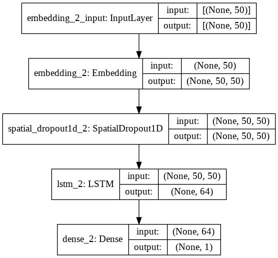

```python
from keras.utils.vis_utils import plot_model
plot_model(model, to_file='/content/model_plot.png', show_shapes=True, show_layer_names=True)
```

```python
submission1=pd.read_csv('/content/sample_submission.csv')
y_pre=model.predict(test)
y_pre=np.round(y_pre).astype(int).reshape(3263)
sub=pd.DataFrame({'id':submission1['id'].values.tolist(),'target':y_pre})
sub.to_csv('/content/submission1.csv',index=False)
```

```python
!kaggle competitions submit -c nlp-getting-started -f /content/submission1.csv -m 'RNN1'
```

```python
!kaggle competitions submissions -c nlp-getting-started
```

```python
### MY KAGGLE USERNAME IS michaelrocchio2
```

```python
model2=Sequential()
embedding=Embedding(num_words,50,embeddings_initializer=Constant(embedding_matrix),input_length=MAX_LEN,trainable=False)
model2.add(embedding)
model2.add(SpatialDropout1D(0.2))
model2.add(LSTM(32, dropout=0.2, recurrent_dropout=0.2))
model2.add(Dense(64, activation='relu'))
model2.add(Dense(1, activation='sigmoid'))
optimzer=Adam(learning_rate=1e-5)
model2.compile(loss='binary_crossentropy',optimizer=optimzer,metrics=['accuracy'])
model2.summary()
```

```
WARNING:tensorflow:Layer lstm_9 will not use cuDNN kernels since it doesn't meet the criteria. It will use a generic GPU kernel as fallback when running on GPU.
Model: "sequential_7"
_________________________________________________________________
Layer (type)                 Output Shape              Param #
=================================================================
embedding_7 (Embedding)      (None, 50, 50)            934950
_________________________________________________________________
spatial_dropout1d_9 (Spatial (None, 50, 50)            0
_________________________________________________________________
lstm_9 (LSTM)                (None, 32)                10624
_________________________________________________________________
dense_3 (Dense)              (None, 64)                2112
_________________________________________________________________
dense_4 (Dense)              (None, 1)                 65
=================================================================
Total params: 947,751
Trainable params: 12,801
Non-trainable params: 934,950
_________________________________________________________________
```

```python
history=model2.fit(X_train,y_train,batch_size=4,epochs=12,validation_data=(X_test,y_test))
```

[output not shown]

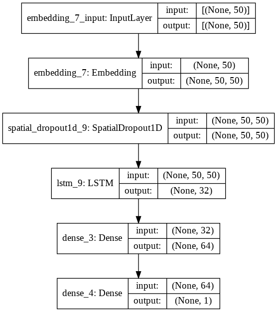

```python
from keras.utils.vis_utils import plot_model
plot_model(model2, to_file='/content/model_plot.png', show_shapes=True, show_layer_names=True)
```

```python
submission2=pd.read_csv('/content/sample_submission.csv')
y_pre=model2.predict(test)
y_pre=np.round(y_pre).astype(int).reshape(3263)
sub=pd.DataFrame({'id':submission1['id'].values.tolist(),'target':y_pre})
sub.to_csv('/content/submission2.csv',index=False)
```

```python
!kaggle competitions submit -c nlp-getting-started -f /content/submission2.csv -m 'RNN2'
```

```python
!kaggle competitions submissions -c nlp-getting-started
```

```python
### my kaggle username is michaelrocchio2
```